# Piloting the manipulation and learning outcome assessment

Stefanie Meliss

2024-05-03

## Key Take Home

- In comparison to the AO, the non-AO elicits epistemic emotions more strongly. The difference is statistically significant for some, but not all epistemic emotions measured here.
- The content of the AO manipulation did not significantly influence performance in the learning outcome assessment.
- Especially MC items in the learning outcome assessment may be too easy and prone to ceiling effects.

## Description of the pilot study

The purpose of this pilot study was to administer the advance organiser (AO) manipulation as well as the learning outcome assessment to teachers to determine whether the AO manipulation affects ratings of epistemic emotions and performance in the learning outcome assessment without having access to the learning materials, i.e., the evidence summary. The manipulation and learning assessments were designed for the use in this project. Additionally, we were interested in determining whether the items included in the learning outcome assessment have the appropriate level of difficulty.

#### Participants and design

Participants were recruited using Twitter. The pilot study was set up in Qualtrics and a distribution link was shared (by SS). In total, the survey was started by 242 participants and completed by **116** participants. Participants were randomly allocated to two groups (control group, n = 54; experimental group, n = 62). The project protocol was approved by University College London’s ethics committee. Participants were informed about the purpose and provided informed consent to participate in the pilot study. Participants were invited to enter a raffle to win one of four Amazon vouchers (£25).

#### Materials and measurements

Each group was presented with introductory material on the topic of literacy. The experimental group was presented with introductory material that meets the criteria of an AO. The control group was presented with a passage on literacy development that matched the AO in overall structure, complexity, and linguistic properties, but they differed in content.  
To measure epistemic emotions elicited through exposure with the introductory material, the seven-item short version of the Epistemic Emotions Scale (Pekrun et al., 2016) was used. For each of the seven epistemic emotions presented (e.g., curious), participants indicated the strength of that emotion on a 5-point Likert scale (1 = “Not at all”, 5 = “Very strong”) that described their emotional response when reading the introductory material. An optional free-text input text box was added, offering participants to opportunity to expand on their rating.  
The learning outcome assessment consisted of 8 short answer questions (e.g., “Complete this sentence: The smallest chunk of meaning within a word is called a __________.”) and 15 four-alternative forced choice questions/statements. For each presented item (e.g., “Which of these words, when spoken aloud, contain a phoneme that is also contained within the word ‘chef’?…”), participants were instructed to select **all correct answers** out of four alternatives they thought as correct (e.g., “Wash”, “March”, “See”, “Phone”). Participants were encouraged to guess but specifically asked to not look up any correct answers. The items and corresponding options were presented in randomised, but constant order, i.e., a custom-made R script was used to randomise the presentation order and the same order was used across all participants.  
The feedback survey consisted of in total 4 items. A 5-point Likert scale (1 = “strongly disagree”, 5 = “strongly agree”) was presented to participants to obtain ratings regarding the wording of the questions (e.g., “The questions in the multiple choice test are worded in a way that is concise.”). An optional free-text input text box was added, offering participants to opportunity to expand on their rating.

#### Procedure

Upon following the Qualtrics survey distribution link, participants were informed about the purpose of the study and asked to provide consent. No identifiable information was recorded but participants were asked to create a study pseudonym should they wish to withdraw their consent. Participants then read one of two introductory materials, ompleted the epistemic emotions scale and learning outcome assessment (presented on a single page each) followed by the feedback survey (presented on one page). Participants took on average **17.09min** to complete the pilot study.

## Results: Epistemic Emotions Scale

As shown below, participants exposed to the non-AO introductory materials experienced all epistemic emotions numerically more intensively. After stringent Bonferoni correction (alpha (k) = .05/7 = .007), the difference remained significant for “confused”.

#### surprised

Descriptives for whole sample

| n | mean | sd | median | trimmed | mad | min | max | range | skew | kurtosis | se |
| --- | --- | --- | --- | --- | --- | --- | --- | --- | --- | --- | --- |
| 116 | 1.681034 | 0.7413165 | 2 | 1.595745 | 1.4826 | 1 | 4 | 3 | 0.7033525 | -0.4415642 | 0.0688295 |

Descriptives within each group

|  | n | mean | sd | median | trimmed | mad | min | max | range | skew | kurtosis | se |
| --- | --- | --- | --- | --- | --- | --- | --- | --- | --- | --- | --- | --- |
| AO | 62 | 1.532258 | 0.6946574 | 1 | 1.420000 | 0.0000 | 1 | 4 | 3 | 1.1860454 | 1.122113 | 0.0882216 |
| non-AO | 54 | 1.851852 | 0.7625035 | 2 | 1.818182 | 1.4826 | 1 | 3 | 2 | 0.2452432 | -1.280104 | 0.1037636 |

```
        Two-Sample t-test, t(108.1965) = -2.346536, p = 0.02076936
```

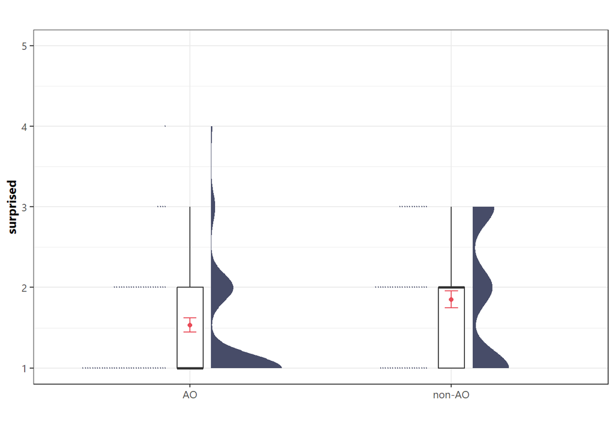

#### curious

Descriptives for whole sample

| n | mean | sd | median | trimmed | mad | min | max | range | skew | kurtosis | se |
| --- | --- | --- | --- | --- | --- | --- | --- | --- | --- | --- | --- |
| 116 | 3.086207 | 0.9190635 | 3 | 3.159575 | 1.4826 | 1 | 5 | 4 | -0.5018886 | 0.204872 | 0.0853329 |

Descriptives within each group

|  | n | mean | sd | median | trimmed | mad | min | max | range | skew | kurtosis | se |
| --- | --- | --- | --- | --- | --- | --- | --- | --- | --- | --- | --- | --- |
| AO | 62 | 3.064516 | 0.9209932 | 3 | 3.160000 | 0.0000 | 1 | 5 | 4 | -0.6200290 | 0.4624972 | 0.1169663 |
| non-AO | 54 | 3.111111 | 0.9248491 | 3 | 3.159091 | 1.4826 | 1 | 5 | 4 | -0.3554788 | -0.2313289 | 0.1258560 |

```
        Two-Sample t-test, t(111.6951) = -0.2711907, p = 0.7867449
```

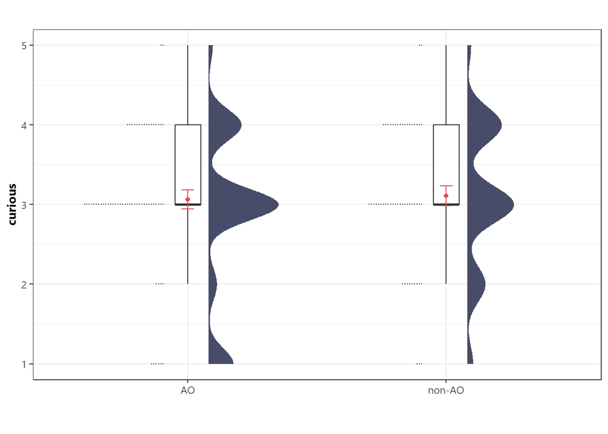

#### excited

Descriptives for whole sample

| n | mean | sd | median | trimmed | mad | min | max | range | skew | kurtosis | se |
| --- | --- | --- | --- | --- | --- | --- | --- | --- | --- | --- | --- |
| 116 | 2.224138 | 1.030713 | 2 | 2.148936 | 1.4826 | 1 | 5 | 4 | 0.3034444 | -0.9199252 | 0.0956993 |

Descriptives within each group

|  | n | mean | sd | median | trimmed | mad | min | max | range | skew | kurtosis | se |
| --- | --- | --- | --- | --- | --- | --- | --- | --- | --- | --- | --- | --- |
| AO | 62 | 2.064516 | 0.955930 | 2 | 2.000000 | 1.4826 | 1 | 4 | 3 | 0.3174840 | -1.1038158 | 0.1214032 |
| non-AO | 54 | 2.407407 | 1.090586 | 2 | 2.363636 | 1.4826 | 1 | 5 | 4 | 0.1899245 | -0.9832896 | 0.1484100 |

```
        Two-Sample t-test, t(106.3053) = -1.788313, p = 0.07657422
```

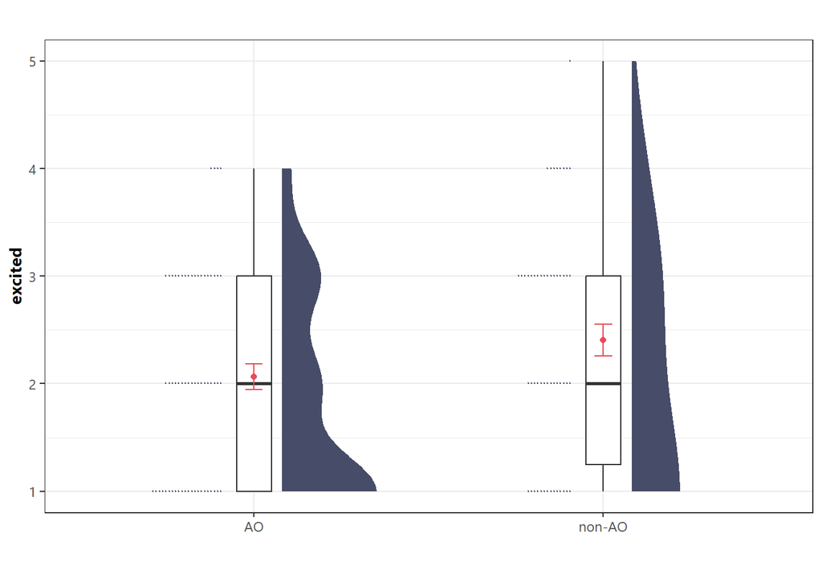

#### confused

Descriptives for whole sample

| n | mean | sd | median | trimmed | mad | min | max | range | skew | kurtosis | se |
| --- | --- | --- | --- | --- | --- | --- | --- | --- | --- | --- | --- |
| 116 | 1.5 | 0.7857425 | 1 | 1.351064 | 0 | 1 | 4 | 3 | 1.439416 | 1.167048 | 0.0729544 |

Descriptives within each group

|  | n | mean | sd | median | trimmed | mad | min | max | range | skew | kurtosis | se |
| --- | --- | --- | --- | --- | --- | --- | --- | --- | --- | --- | --- | --- |
| AO | 62 | 1.290323 | 0.6110216 | 1 | 1.160000 | 0 | 1 | 4 | 3 | 2.3082618 | 5.5777045 | 0.0775998 |
| non-AO | 54 | 1.740741 | 0.8941146 | 1 | 1.636364 | 0 | 1 | 4 | 3 | 0.8263413 | -0.5154678 | 0.1216736 |

```
        Two-Sample t-test, t(91.70223) = -3.121123, p = 0.002409548 ***
```

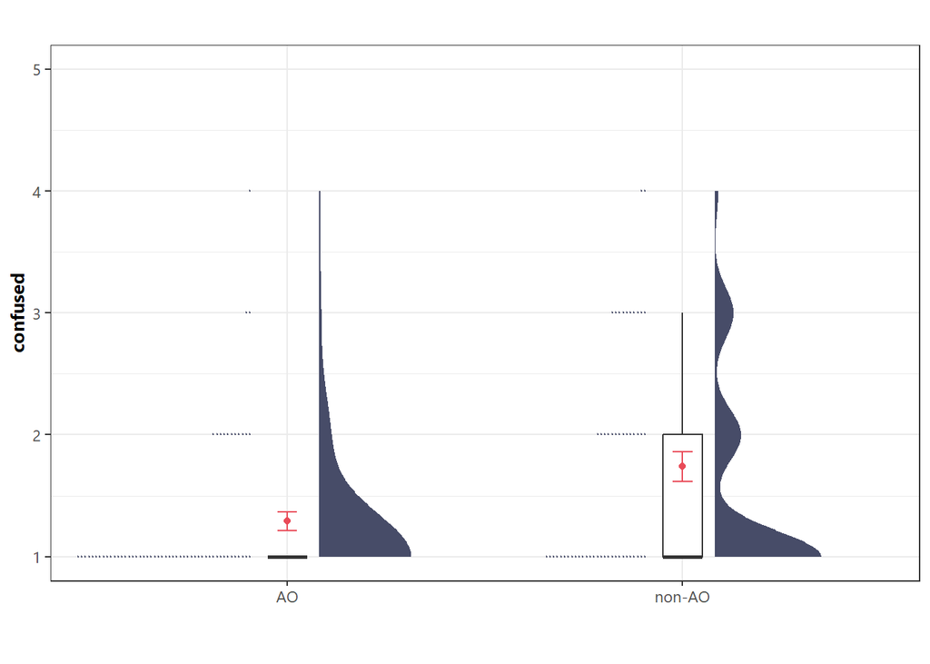

#### anxious

Descriptives for whole sample

| n | mean | sd | median | trimmed | mad | min | max | range | skew | kurtosis | se |
| --- | --- | --- | --- | --- | --- | --- | --- | --- | --- | --- | --- |
| 116 | 1.301724 | 0.6354708 | 1 | 1.148936 | 0 | 1 | 4 | 3 | 2.075333 | 3.56109 | 0.059002 |

Descriptives within each group

|  | n | mean | sd | median | trimmed | mad | min | max | range | skew | kurtosis | se |
| --- | --- | --- | --- | --- | --- | --- | --- | --- | --- | --- | --- | --- |
| AO | 62 | 1.193548 | 0.5069585 | 1 | 1.060000 | 0 | 1 | 3 | 2 | 2.531223 | 5.438777 | 0.0643838 |
| non-AO | 54 | 1.425926 | 0.7423027 | 1 | 1.272727 | 0 | 1 | 4 | 3 | 1.607808 | 1.692453 | 0.1010146 |

```
        Two-Sample t-test, t(91.66467) = -1.939903, p = 0.05546565
```

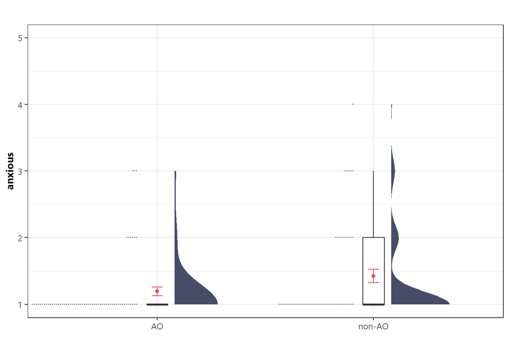

#### frustrated

Descriptives for whole sample

| n | mean | sd | median | trimmed | mad | min | max | range | skew | kurtosis | se |
| --- | --- | --- | --- | --- | --- | --- | --- | --- | --- | --- | --- |
| 116 | 1.37931 | 0.7301599 | 1 | 1.212766 | 0 | 1 | 5 | 4 | 2.212404 | 5.464935 | 0.0677936 |

Descriptives within each group

|  | n | mean | sd | median | trimmed | mad | min | max | range | skew | kurtosis | se |
| --- | --- | --- | --- | --- | --- | --- | --- | --- | --- | --- | --- | --- |
| AO | 62 | 1.322581 | 0.7845682 | 1 | 1.120000 | 0 | 1 | 5 | 4 | 2.791433 | 8.0693526 | 0.0996403 |
| non-AO | 54 | 1.444444 | 0.6635146 | 1 | 1.318182 | 0 | 1 | 3 | 2 | 1.150502 | 0.0550558 | 0.0902929 |

```
        Two-Sample t-test, t(113.9102) = -0.9062825, p = 0.3666994
```

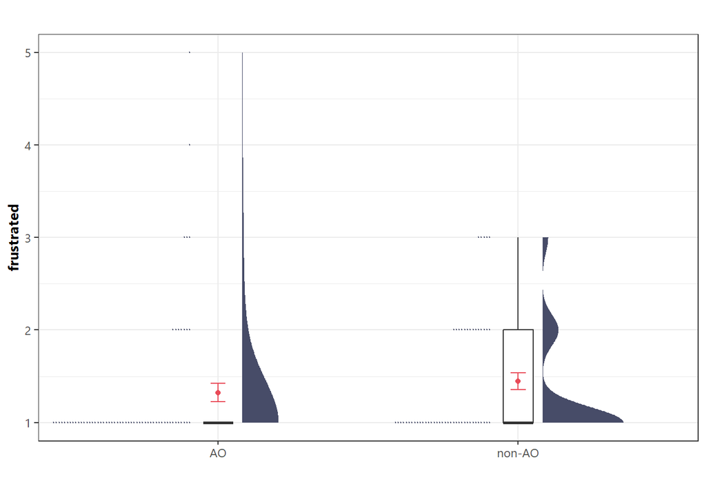

#### bored

Descriptives for whole sample

| n | mean | sd | median | trimmed | mad | min | max | range | skew | kurtosis | se |
| --- | --- | --- | --- | --- | --- | --- | --- | --- | --- | --- | --- |
| 116 | 1.948276 | 0.9855021 | 2 | 1.829787 | 1.4826 | 1 | 5 | 4 | 0.7506896 | -0.299796 | 0.0915016 |

Descriptives within each group

|  | n | mean | sd | median | trimmed | mad | min | max | range | skew | kurtosis | se |
| --- | --- | --- | --- | --- | --- | --- | --- | --- | --- | --- | --- | --- |
| AO | 62 | 1.774193 | 0.8762692 | 2 | 1.660000 | 1.4826 | 1 | 4 | 3 | 0.8736012 | -0.1432886 | 0.1112863 |
| non-AO | 54 | 2.148148 | 1.0711906 | 2 | 2.045454 | 1.4826 | 1 | 5 | 4 | 0.5242403 | -0.6744137 | 0.1457706 |

```
        Two-Sample t-test, t(102.5245) = -2.039067, p = 0.04401628
```

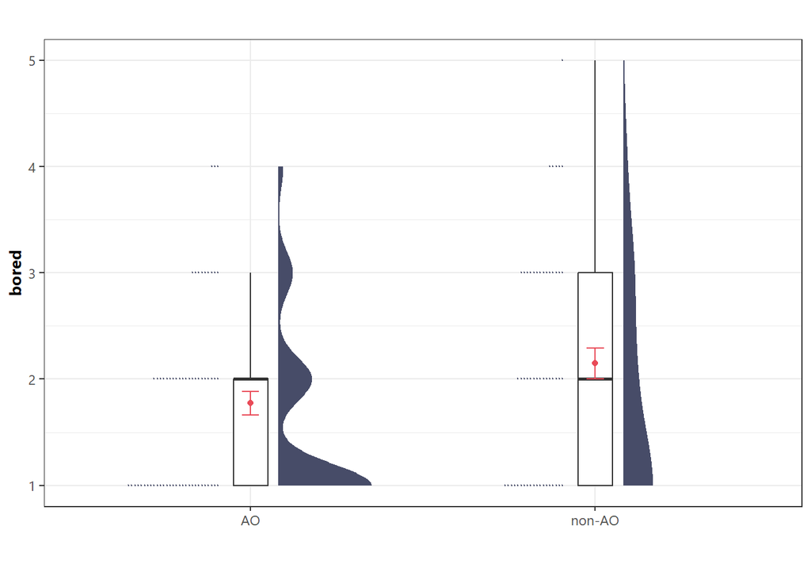

To summarise above, the average rating of the intensity of each emotion (and its standard error) was computed for each group.

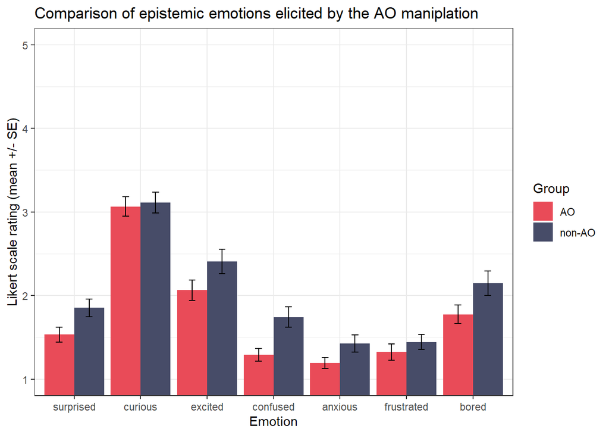

Due to the puzzling results that somehow contradicting epistemic emotions (e.g., feeling excited vs bored) are higher in the group that was presented with the non-AO, the profile for each participant was plotted.

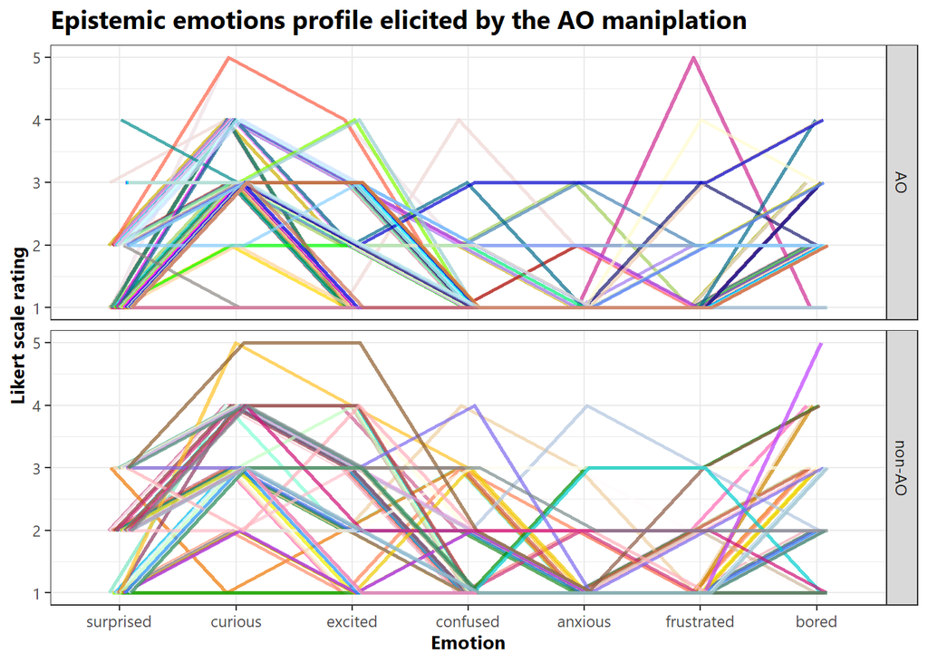

Participants were also provided with the option to expand on the rating using comments.

```
##
##
## Curiosity and excitement as I am intrigued to know more about your research.
##
## noo
##
## It said little that I didn’t already know
##
## The analogy is great
##
## I thought it was a decent analogy to introduce to trainee teachers.
##
## May have been more anxious because I cannot yet drive myself and the thought of learning makes me anxious!
##
## I feel the analogy worked well
##
## I liked the analogy of teaching someone to drive - it makes sense to me as a teacher who knows the components of reading and I imagine it could pique the interest of someone who does not
##
## Clever analogy - could have been delivered in a lot less words.
##
## I don’t think it elicited an emotional response in me. It is an interesting piece of writing based on things that I had some knowledge of. It made me think about power and social justice (about those who were able to learn to read and write historically).
##
## I was able to follow the train of thought and it made me interested enough to want to learn more.
##
## It took a couple of times to read the first paragraph before I understood it.
##
## I also work in driver education. The context immediately caught my attention.
##
## Doesn’t tell me anything new
##
## Teachers understand that reading is something to be broken down and for readers to be given a lot of practice with, they don’t need an analogy to explain this to them.
##
## I thought the parrarel between reading and driving was a very good method used as an introduction to understanding how complex reading is and the approach we must take in teaching.
```

## Results: Performance in the learning outcome assessment

The learning outcome assessment consisted of cued recall (free text format) and cued recognition (four-alternative forced choice) items. Below, performance is determined for both types of questions separately.

### Free text format items

The learning outcome assessment contained eight free text format items. For each item, the correct solution was determined before the assessment was administered. Additionally, upon viewing the answers (blind of condition), additional acceptable responses were determined *in an iterative process*.

#### Performance for each item

Based on the first iteration, the results are shown below. For each item, the item text together with the correct response is shown, followed by all unique answers given (blind of group), and the accepted stems used in the partial string comparison. Additionally, the success rate was computed for each item, i.e., the total percentage of participants that were awarded a point for the respective item.

i6 **ITEM: Complete this sentence: The smallest chunk of meaning within a word is called a __________.**

*CORRECT:* morpheme

*GIVEN ANSWERS:* -/- grapheme -/- unsure -/- i don’t know -/- -/- phoneme -/- unsure -/- root/prefix/suffix (morpheme) -/- morpheme -/- word -/- clause -/- morpheme -/- syllable -/- phoneme -/- morpheme? -/- a -/- don’t know -/- letter -/- ideogram -/- don’t know- sorry -/- subword -/- letter -/- root -/- root word -/- ? -/- unknown -/- sound/phoneme -/- not sure -/- signifier -/- morphemes -/- not sure - sorry! -/- comprehension -/- sylable -/- word

*ACCEPTED STEMS:* -/- morpheme

*SUCESS RATE:* 44.82759%

i8 **ITEM: Brief teaching of different ____________ can be used to ensure that pupils are consciously aware that reading is an active constructive process.**

*CORRECT:* (comprehension) strategies

*GIVEN ANSWERS:* -/- texts -/- strategies -/- i don’t know -/- vocabulary -/- phonemes -/- interpretations -/- unsure -/- morphemes -/- ? -/- meaning -/- -/- strategies -/- no idea -/- morphemes -/- prefixes -/- texts -/- skills -/- definitions -/- phonological awareness -/- ??? -/- startegies -/- ways -/- hfjf -/- words -/- vocabulary -/- word meanings -/- dont know -/- reading strategies (summarising, predicting, asking questions, inferring, clarifying and evaluating) -/- reading strategies -/- comprehension strategies -/- word constructions -/- techniques -/- meanings -/- contexts -/- unknown -/- genres -/- don’t know -/- suffixes and prefixes -/- no idea -/- inference skills -/- don’t know -/- languages -/- text types -/- sounds -/- methods -/- reading techniques -/- phonemes -/- comprehension strategies -/- extracts -/- phonemes and graphemes

*ACCEPTED STEMS:* -/- strateg -/- startegies

*SUCESS RATE:* 25%

i10 **ITEM: Complete this sentence: The approaches to reading and writing that are tailored to the purposes, methods, and content of a particular area of academic study are called ____________ literacy.**

*CORRECT:* disciplinary

*GIVEN ANSWERS:* -/- academic -/- disciplinary -/- disciplinary -/- domain? -/- -/- development -/- domain-specific -/- no idea -/- digital -/- functional -/- no idea -/- oral -/- written -/- contextual -/- subject -/- subject specific -/- don’t know -/- ? -/- specific -/- ??? -/- functional -/- teach -/- 5 -/- contextual -/- disaplinary -/- academic -/- specific -/- specialist -/- discipline -/- explicit -/- -/- subject -/- pedagogy -/- unknown -/- … -/- phonic -/- domain -/- accademic -/- phonemic -/- curriculum -/- don’t know -/- don’t kmow -/- comprehensive -/- text -/- applied -/- reading -/- not sure -/- domain specific -/- language -/- domain specific -/- information

*ACCEPTED STEMS:* -/- disciplin -/- disaplin -/- specific -/- -specific

*SUCESS RATE:* 23.27586%

i11 **ITEM: How many graphemes are there in the word ‘bracket’?**

*CORRECT:* 6

*GIVEN ANSWERS:* -/- 7 -/- 3 -/- 2 -/- -/- 6 -/- 5 -/- 4 -/- 1 -/- 0 -/- 100 -/- 25

*ACCEPTED STEMS:* -/- 6

*SUCESS RATE:* 35.34483%

i13 **ITEM: Complete this sentence: The process of reasoning when reading that goes beyond the literal meaning of the text is called __________.**

*CORRECT:* inference/reasoning

*GIVEN ANSWERS:* -/- inference -/- inference -/- deduction? -/- -/- metaphorical -/- comprehension -/- meaning -/- rationalising -/- inferences -/- inferring -/- figurative -/- ??? -/- literal -/- jj -/- inferring / inference -/- comprehension -/- imference -/- infering -/- interpreting -/- inferences -/- inferring -/- breathing -/- infering/ inferences -/- inferencing -/- deduction -/- subtext -/- inference/inferring -/- deduction -/- critical reading

*ACCEPTED STEMS:* -/- infer -/- deduct -/- reason

*SUCESS RATE:* 81.03448%

i17 **ITEM: Complete this sentence: A grapheme can be understood as an individual letter or a set of letters that represents a __________.**

*CORRECT:* phoneme

*GIVEN ANSWERS:* -/- sound -/- unit -/- word? -/- -/- word -/- sound/phoneme -/- two -/- sound -/- phoneme -/- phoneme -/- alone -/- 8 -/- word sound -/- meaning -/- a phoneme in written form. -/- contrasting unit -/- sound (phoneme) -/- picture -/- smallest unit of written language -/- word -/- single unit of sound -/- single phoneme -/- meaningful sound

*ACCEPTED STEMS:* -/- phoneme -/- sound -/- unit

*SUCESS RATE:* 84.48276%

i21 **ITEM: Please complete the following sentence: With extensive practice, the process of word recognition develops a sense of flow. This flow of words is called ___________________.**

*CORRECT:* (reading) fluency

*GIVEN ANSWERS:* -/- fluency -/- prosody -/- unsure -/- fluency -/- -/- automaticity -/- unsure -/- paragraph -/- not sure -/- morpheme -/- blending -/- automaticity -/- prosody -/- grammar -/- 4 -/- pace -/- automatic speed -/- - -/- reading -/- dluency3 -/- exhaling -/- reading fluency -/- no idea -/- phonics -/- othographic mapping -/- cohesion -/- word recognition

*ACCEPTED STEMS:* -/- fluency -/- dluency3 -/- prosody -/- automaticity

*SUCESS RATE:* 77.58621%

i22 **ITEM: How many morphemes are there in the word ‘regained’?**

*CORRECT:* 3

*GIVEN ANSWERS:* -/- 6 -/- 2 -/- 3 -/- 0 -/- -/- 7 -/- 8 -/- 1 -/- 4 -/- 5 -/- 100

*ACCEPTED STEMS:* -/- 3

*SUCESS RATE:* 47.41379%

> > To ensure good item selection and coding, the success rate should allow maximum variance, i.e., be around 50%.

> > Based on the current coding framework, items **i6** and **i22** are close to 50%. However, both target a similar topic, i.e., morphemes.  
> > Other items have success rates that are well above 50%, i.e., **i13** (on inference), **i17** (on phonemes), and **i21** (on fluency). Of note, for items i17 and i21, the accepted answers could be streamlined to be less lenient.

> > Items **i8** (on comprehension strategies), **i10** (on disciplinary literacy), and **i11** (on graphemes) have success rates below 50%. However, it is important to keep in mind that participants in this pilot study were *not* exposed to the actual learning materials that contains the tested information.

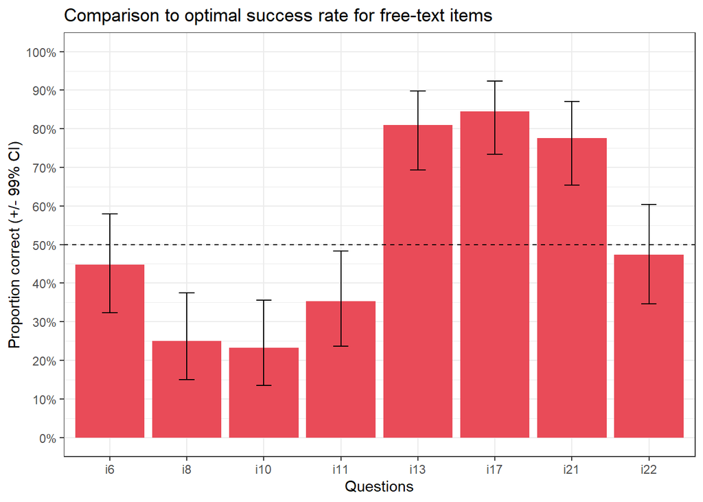

#### Overall performance

As a last step, the descriptives for the performance across all free text answer items was computed across the whole sample and within each group. A t-test revealed that there was no difference in performance between both groups.

Descriptives for whole sample

| n | mean | sd | median | trimmed | mad | min | max | range | skew | kurtosis | se |
| --- | --- | --- | --- | --- | --- | --- | --- | --- | --- | --- | --- |
| 116 | 4.189655 | 1.698663 | 4 | 4.244681 | 1.4826 | 0 | 8 | 8 | -0.3475238 | -0.0737918 | 0.1577169 |

Descriptives within each group

|  | n | mean | sd | median | trimmed | mad | min | max | range | skew | kurtosis | se |
| --- | --- | --- | --- | --- | --- | --- | --- | --- | --- | --- | --- | --- |
| AO | 62 | 4.145161 | 1.744751 | 4 | 4.200000 | 1.4826 | 0 | 8 | 8 | -0.2734774 | -0.2225328 | 0.2215836 |
| non-AO | 54 | 4.240741 | 1.658997 | 4 | 4.295454 | 1.4826 | 0 | 7 | 7 | -0.4262748 | 0.0101607 | 0.2257609 |

```
        Two-Sample t-test, t(113.1027) = -0.3021471, p = 0.7630948
```

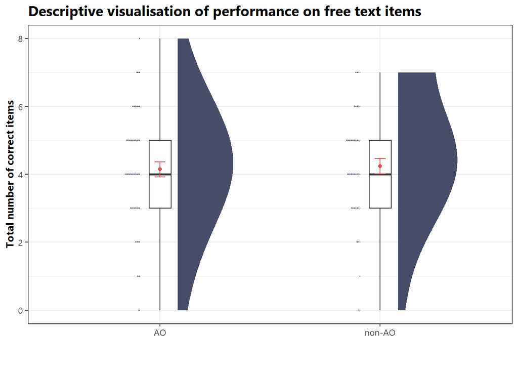

### Multiple choice items

The learning outcome assessment contained 15 multiple-choice format items. For each item with its four answer option, the pattern of selected/unselected options was compared against the correct pattern. This means that a point was awarded if an option was correctly selected *and* if an option was correctly not selected. As such, for each item, the maximum score is 4.

#### Performance for each item

Below, the results are shown for each item separately (blind of group). The item text is plotted together with the correct options. A plot was created that illustrates how often each response option was selected (correct options highlighted), together with the success rate for deciding correctly for each option (in coral). Descriptives of the performance on the given item (maximum possible score 4, minimum possible score 0) were computed as well.

**i1. Which of these might be a way of detecting a pupil’s oral reading fluency? (Select all correct answers.)**

1. Reading speed.
2. Correct decoding of words.
3. Appropriate stress of words.
4. Appropriate intonation of words.

*[solution: Appropriate intonation of words. / Reading speed. / Correct decoding of words. / Appropriate stress of words.]*

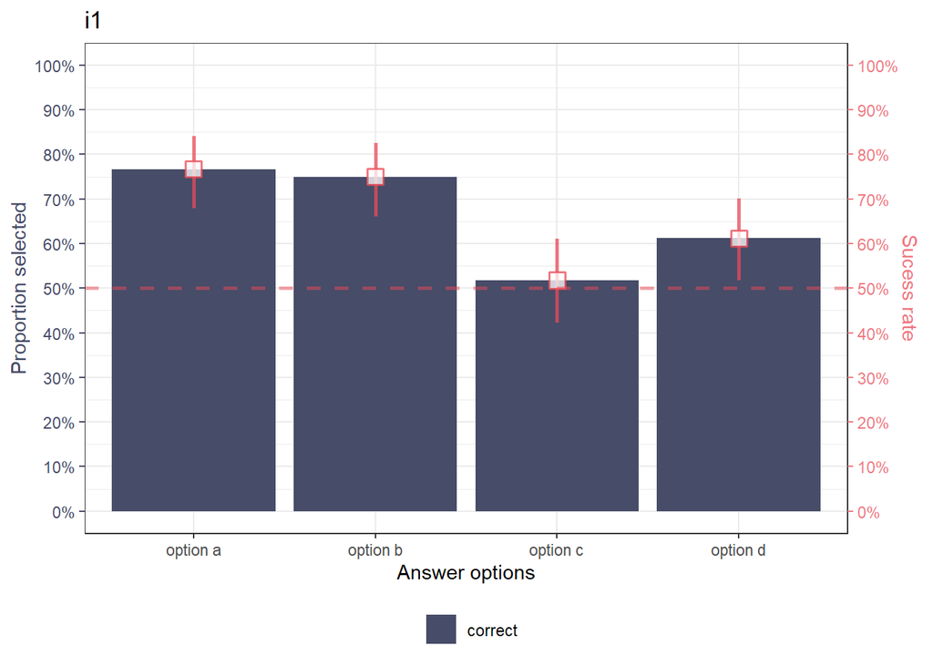

| n | mean | sd | median | trimmed | mad | min | max | range | skew | kurtosis | se |
| --- | --- | --- | --- | --- | --- | --- | --- | --- | --- | --- | --- |
| 116 | 2.646552 | 1.105357 | 3 | 2.680851 | 1.4826 | 1 | 4 | 3 | -0.0822816 | -1.373568 | 0.1026298 |

**i2. Which pupils might benefit most from being taught how and when to summarise what they read and ask questions about what they read? (Select all correct answers.)**

1. Pupils who lack the vocabulary to read academic texts.
2. Pupils who recognise individual words adequately, but who struggle to read fluently.
3. Pupils who appear to be relatively fluent readers but who pay little attention to building meaning as they read.
4. Pupils who struggle to decode words.

*[solution: Pupils who appear to be relatively fluent readers but who pay little attention to building meaning as they read.]*

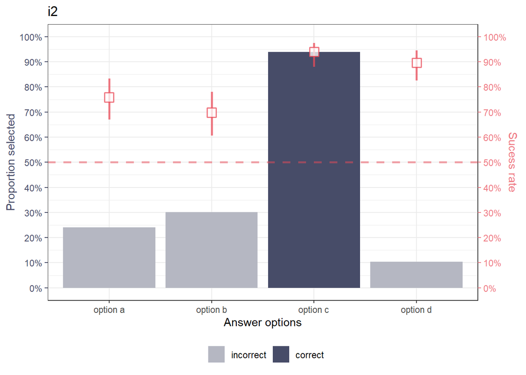

| n | mean | sd | median | trimmed | mad | min | max | range | skew | kurtosis | se |
| --- | --- | --- | --- | --- | --- | --- | --- | --- | --- | --- | --- |
| 116 | 3.293103 | 0.9419429 | 4 | 3.43617 | 0 | 1 | 4 | 3 | -1.038109 | -0.1468684 | 0.0874572 |

**i3. Which of these words, when spoken aloud, contain a phoneme that is also contained within the word ‘chef’? (Select all correct answers.)**

1. March
2. Wash
3. Phone
4. See

*[solution: Wash]*

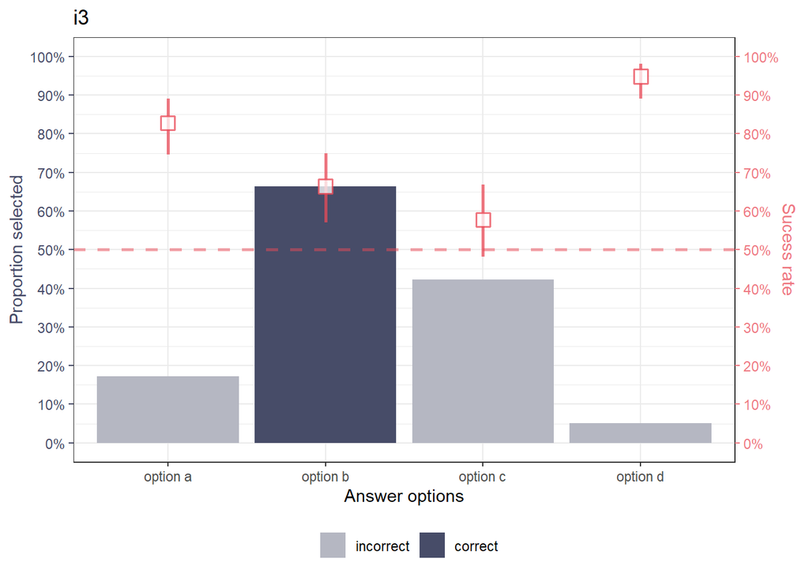

| n | mean | sd | median | trimmed | mad | min | max | range | skew | kurtosis | se |
| --- | --- | --- | --- | --- | --- | --- | --- | --- | --- | --- | --- |
| 116 | 3.017241 | 0.8844822 | 3 | 3.042553 | 1.4826 | 1 | 4 | 3 | -0.1825704 | -1.382229 | 0.0821221 |

**i4. A text says, ‘Harriet kicked the ball into the net and ran off with her arms in the air.’ A reader reasons that Harriet is likely to be playing football. This is an example of an inference because… (Select all correct answers.)**

1. It requires the reader to ignore some of the words and focus on others.
2. It requires the reader to draw a conclusion that isn’t literally stated in the text.
3. It requires the reader to read sentences that came before this one.
4. It requires the reader to recognise every word.

*[solution: It requires the reader to draw a conclusion that isn’t literally stated in the text.]*

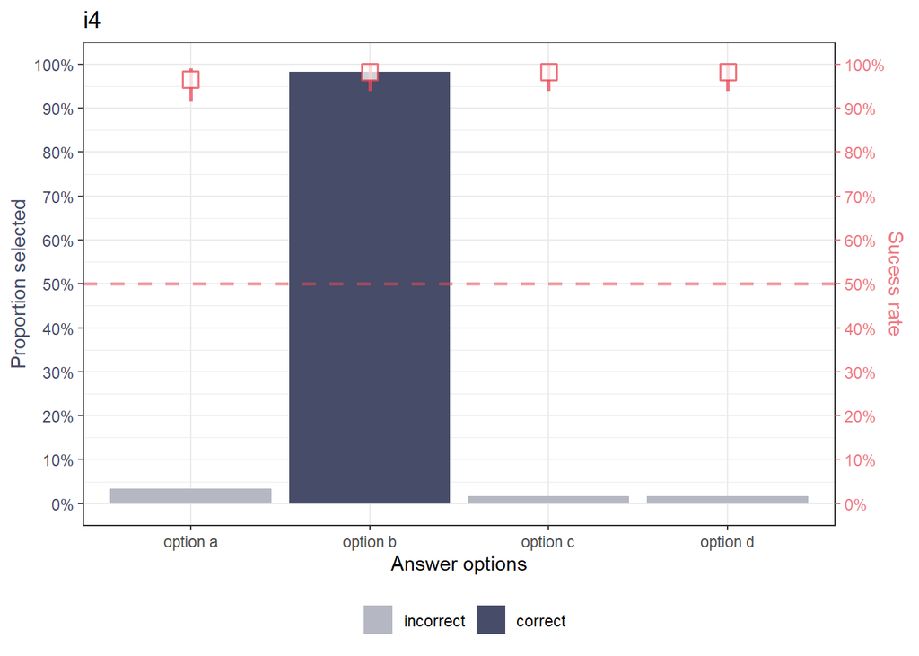

| n | mean | sd | median | trimmed | mad | min | max | range | skew | kurtosis | se |
| --- | --- | --- | --- | --- | --- | --- | --- | --- | --- | --- | --- |
| 116 | 3.913793 | 0.3379983 | 4 | 4 | 0 | 2 | 4 | 2 | -4.136428 | 17.48845 | 0.0313824 |

**i5. A literacy lead and a science lead are designing the science curriculum to support pupils’ reading development. Which of these are likely to be useful elements of such a curriculum? (Select all correct answers.)**

1. Carefully sequenced content to help build knowledge of the world.
2. Selected key scientific words to be taught to pupils.
3. Texts embedded into the curriculum that provide opportunities for reading practice.
4. Opportunities to draw inferences from pictures.

*[solution: Carefully sequenced content to help build knowledge of the world. / Selected key scientific words to be taught to pupils. / Texts embedded into the curriculum that provide opportunities for reading practice.]*

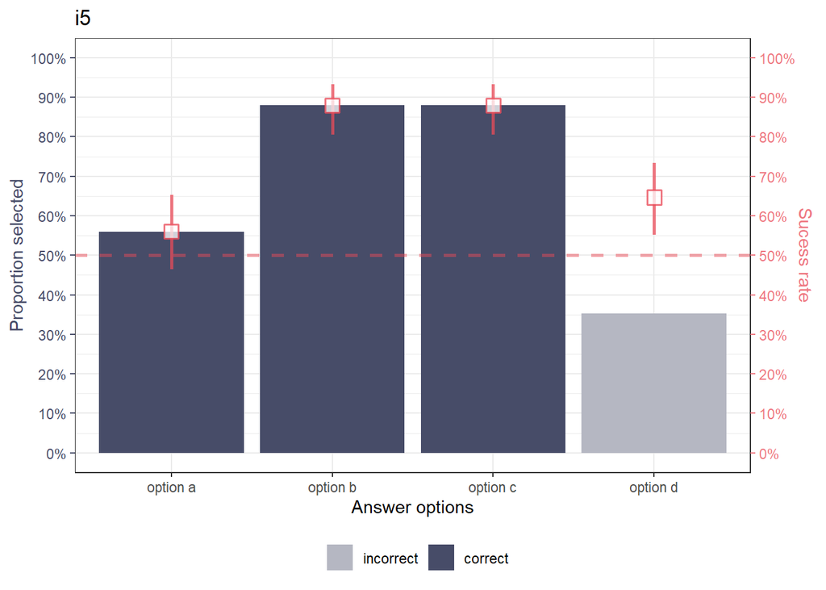

| n | mean | sd | median | trimmed | mad | min | max | range | skew | kurtosis | se |
| --- | --- | --- | --- | --- | --- | --- | --- | --- | --- | --- | --- |
| 116 | 2.965517 | 0.6969628 | 3 | 2.968085 | 0 | 1 | 4 | 3 | -0.1073633 | -0.5514652 | 0.0647114 |

**i7. Understanding the role of morphemes in the English writing system is most likely to support… (Pick the two most appropriate answers)**

1. Vocabulary development.
2. Comprehension strategy use.
3. Word recognition.
4. Background knowledge development.

*[solution: Word recognition. / Vocabulary development.]*

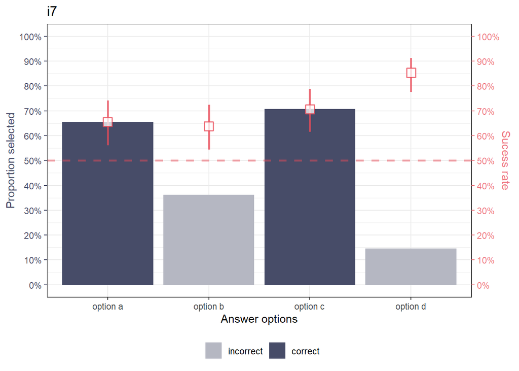

| n | mean | sd | median | trimmed | mad | min | max | range | skew | kurtosis | se |
| --- | --- | --- | --- | --- | --- | --- | --- | --- | --- | --- | --- |
| 116 | 2.853448 | 0.9802778 | 3 | 2.914894 | 1.4826 | 0 | 4 | 4 | -0.3116028 | -0.8084895 | 0.0910165 |

**i9. Which of these overlapping bodies of knowledge most directly contribute to language comprehension? (Pick the two most appropriate answers.)**

1. Vocabulary.
2. Phonemic awareness.
3. Knowledge of sentence structure.
4. Knowledge of the ‘code’ of correspondences between phonemes and graphemes.

*[solution: Vocabulary. / Knowledge of sentence structure.]*

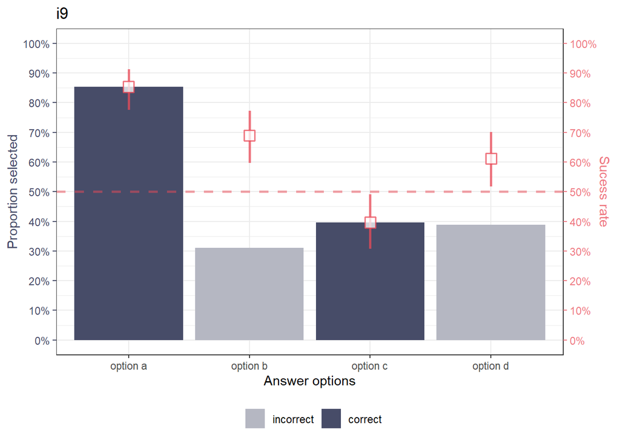

| n | mean | sd | median | trimmed | mad | min | max | range | skew | kurtosis | se |
| --- | --- | --- | --- | --- | --- | --- | --- | --- | --- | --- | --- |
| 116 | 2.551724 | 1.203942 | 2 | 2.638298 | 1.4826 | 0 | 4 | 4 | -0.2241849 | -0.8377779 | 0.1117832 |

**i12. Which of these are examples of comprehension strategies that might be used by pupils to support them to build meaning from a challenging text? (Select all correct answers.)**

1. Summarising.
2. Clarifying.
3. Blending.
4. Highlighting.

*[solution: Clarifying. / Summarising.]*

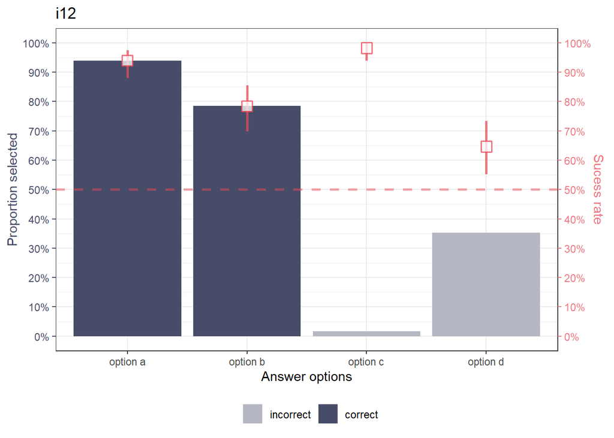

| n | mean | sd | median | trimmed | mad | min | max | range | skew | kurtosis | se |
| --- | --- | --- | --- | --- | --- | --- | --- | --- | --- | --- | --- |
| 116 | 3.353448 | 0.6884679 | 3 | 3.446808 | 1.4826 | 1 | 4 | 3 | -0.7375724 | -0.0144987 | 0.0639226 |

**i14. A pupil’s reading comprehension appears to be significantly below age-related expectations. Weaknesses with which aspect(s) of reading might contribute to this? (Select all correct answers.)**

1. Fluency.
2. Awareness of the difference between Tier 2 and Tier 3 vocabulary.
3. Background knowledge relevant to the texts in the assessment.
4. Word recognition.

*[solution: Word recognition. / Fluency. / Background knowledge relevant to the texts in the assessment.]*

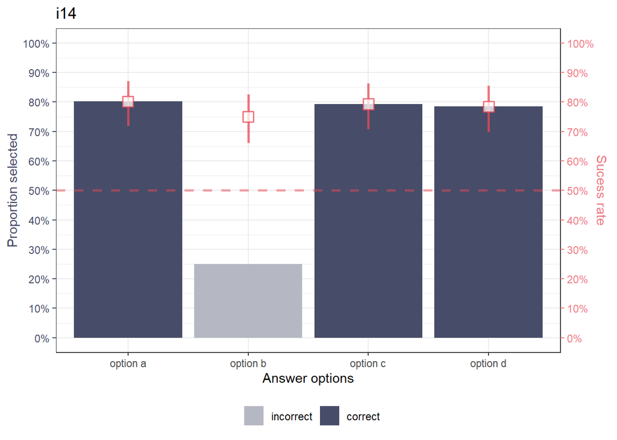

| n | mean | sd | median | trimmed | mad | min | max | range | skew | kurtosis | se |
| --- | --- | --- | --- | --- | --- | --- | --- | --- | --- | --- | --- |
| 116 | 3.12931 | 0.8800215 | 3 | 3.244681 | 1.4826 | 1 | 4 | 3 | -0.8576152 | 0.0630585 | 0.0817079 |

**i15. With respect to word recognition, which of the following statements are true? (Select all correct answers.)**

1. Systematic synthetic morphology is the most effective approach for teaching pupils to decode.
2. Evidence suggests that the teaching of graphemes and phonemes benefits from an organised curriculum.
3. Segmenting is an essential phonemic skill for spelling, but learning how to do it also develops an awareness of phonemes that supports reading development.
4. English orthography is shallow, meaning that it is characterised by a high degree of correspondence between phonemes and graphemes.

*[solution: Segmenting is an essential phonemic skill for spelling, but learning how to do it also develops an awareness of phonemes that supports reading development. / Evidence suggests that the teaching of graphemes and phonemes benefits from an organised curriculum.]*

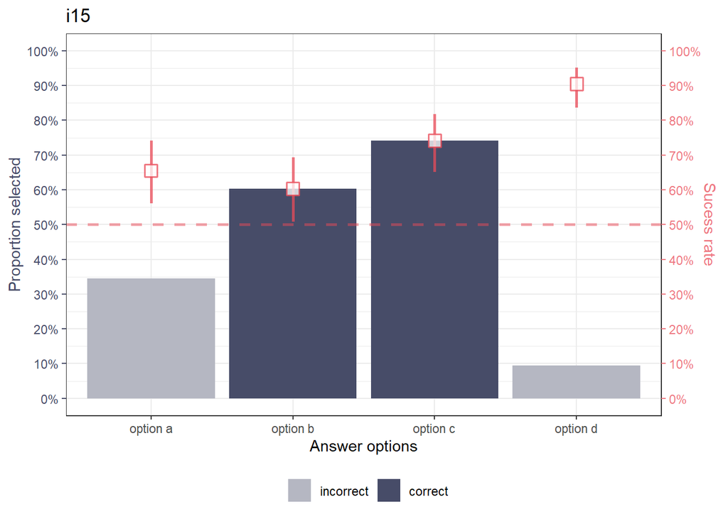

| n | mean | sd | median | trimmed | mad | min | max | range | skew | kurtosis | se |
| --- | --- | --- | --- | --- | --- | --- | --- | --- | --- | --- | --- |
| 116 | 2.905172 | 0.968894 | 3 | 3.010638 | 1.4826 | 0 | 4 | 4 | -0.6083804 | -0.3507987 | 0.0899596 |

**i16. As a result of extensive decoding practice, the quality of in-classroom discussions of new texts noticeably increases. How might this be explained? (Select all correct answers.)**

1. Recognising the correspondence between graphemes and phonemes becomes less automated and error prone.
2. Fluency has improved, meaning pupils have more working memory available to dedicate to building meaning from the texts.
3. The pupils have learned that they do not need to accurately recognise the words in order to make meaning from the text.
4. The pupils’ level of prosody has reduced.

*[solution: Fluency has improved, meaning pupils have more working memory available to dedicate to building meaning from the texts.]*

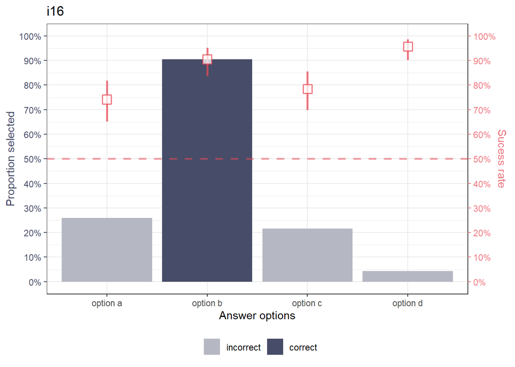

| n | mean | sd | median | trimmed | mad | min | max | range | skew | kurtosis | se |
| --- | --- | --- | --- | --- | --- | --- | --- | --- | --- | --- | --- |
| 116 | 3.387931 | 0.7549437 | 4 | 3.5 | 0 | 1 | 4 | 3 | -1.002786 | 0.2604709 | 0.0700948 |

**i18. The set of conventions of a writing system are called… (Select all correct answers.)**

1. An orthography.
2. A phonics system.
3. A phonology.
4. A morphology.

*[solution: An orthography.]*

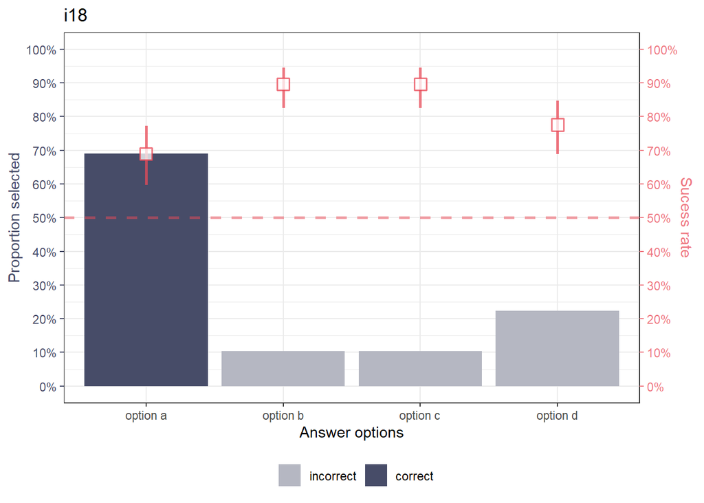

| n | mean | sd | median | trimmed | mad | min | max | range | skew | kurtosis | se |
| --- | --- | --- | --- | --- | --- | --- | --- | --- | --- | --- | --- |
| 116 | 3.258621 | 1.005383 | 4 | 3.37234 | 0 | 0 | 4 | 4 | -0.8838724 | -0.531012 | 0.0933475 |

**i19. A pupil takes two reading comprehension assessments on the same day. The pupil achieves two very different scores on these assessments. This suggests that… (Select all correct answers.)**

1. The pupil improved their reading fluency significantly.
2. The tests required different vocabulary and background knowledge.
3. Reading comprehension tests are of no value.
4. The results of individual comprehension assessments should not be treated as a definitive guide to a pupil’s reading ability.

*[solution: The tests required different vocabulary and background knowledge. / The results of individual comprehension assessments should not be treated as a definitive guide to a pupil’s reading ability.]*

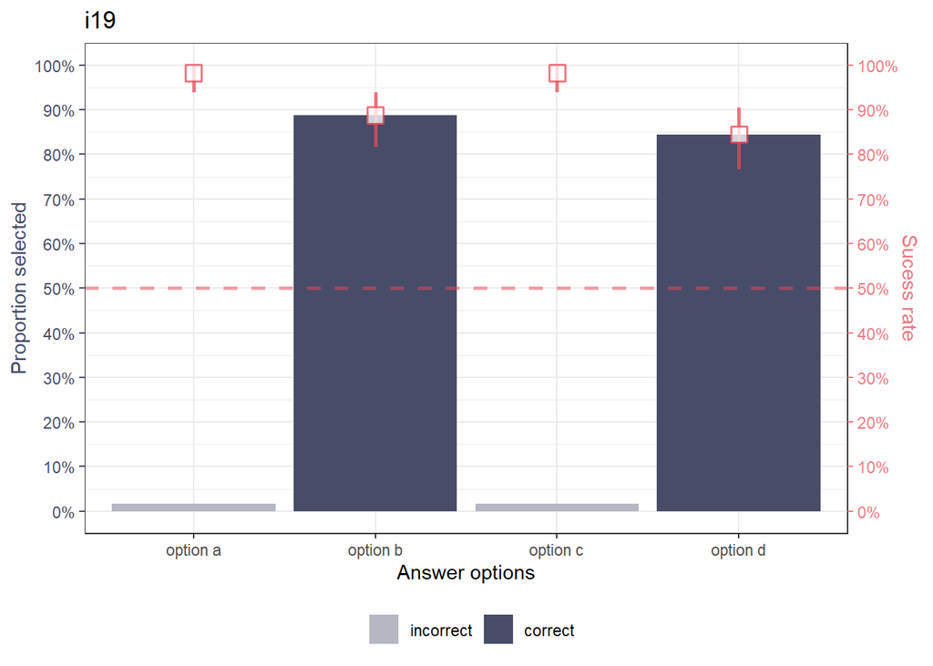

| n | mean | sd | median | trimmed | mad | min | max | range | skew | kurtosis | se |
| --- | --- | --- | --- | --- | --- | --- | --- | --- | --- | --- | --- |
| 116 | 3.698276 | 0.5311158 | 4 | 3.776596 | 0 | 1 | 4 | 3 | -1.867205 | 4.492215 | 0.0493129 |

**i20. Which aspects are important to consider when designing reading comprehension lessons? (Select all correct answers.)**

1. Comprehension of text is facilitated by reading fluency, but comprehension does not facilitate reading fluency.
2. Subject-specific approaches include exposure to a variety of text types and aim to increase the breadth, but not depth, of pupils’ vocabulary.
3. The teaching of reading comprehension should occur in key stages 1 and 2, but not in key stages 3 and 4.
4. Reading comprehension lessons should not be entirely based upon answering questions in writing as this reduces the amount of time spent reading texts.

*[solution: Reading comprehension lessons should not be entirely based upon answering questions in writing as this reduces the amount of time spent reading texts.]*

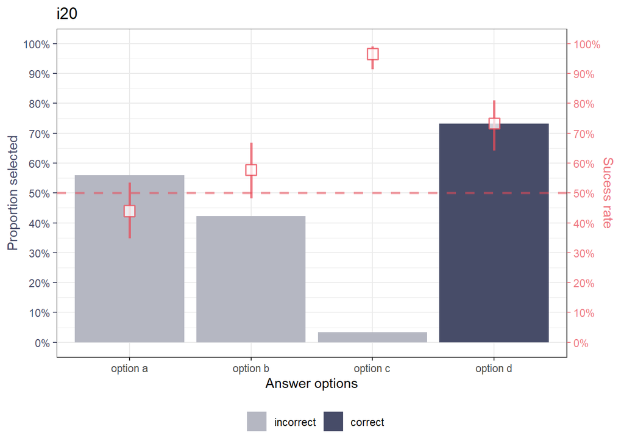

| n | mean | sd | median | trimmed | mad | min | max | range | skew | kurtosis | se |
| --- | --- | --- | --- | --- | --- | --- | --- | --- | --- | --- | --- |
| 116 | 2.715517 | 0.852679 | 3 | 2.744681 | 1.4826 | 1 | 4 | 3 | -0.1803638 | -0.6373041 | 0.0791693 |

**i23. Inferences are… (Select all correct answers.)**

1. Central to the construction of meaning when reading.
2. Made by readers when they reach conclusions that go beyond the literal meaning of the text.
3. Only made by a person when they are reading.
4. Required only when reading narrative texts.

*[solution: Made by readers when they reach conclusions that go beyond the literal meaning of the text. / Central to the construction of meaning when reading.]*

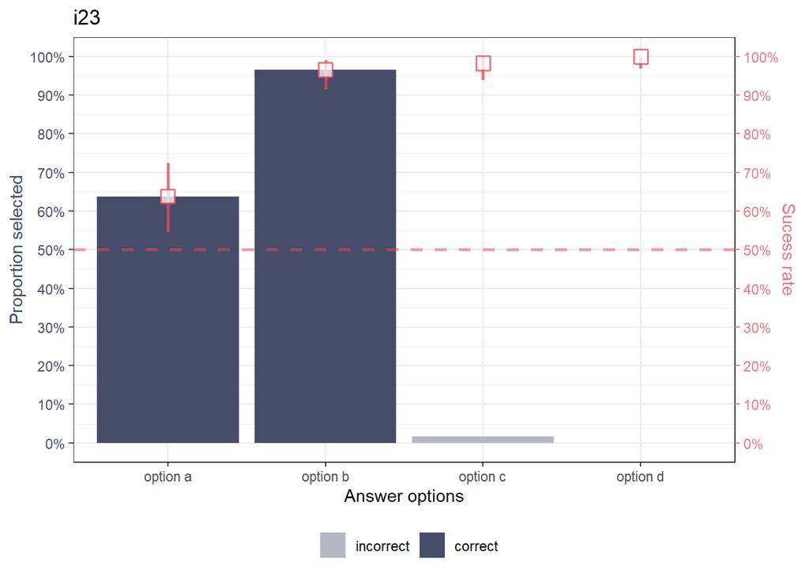

| n | mean | sd | median | trimmed | mad | min | max | range | skew | kurtosis | se |
| --- | --- | --- | --- | --- | --- | --- | --- | --- | --- | --- | --- |
| 116 | 3.586207 | 0.5907838 | 4 | 3.648936 | 0 | 1 | 4 | 3 | -1.586804 | 3.83192 | 0.0548529 |

> As shown above, the items and corresponding answer options may overall be too easy so that ceiling effects are likely.

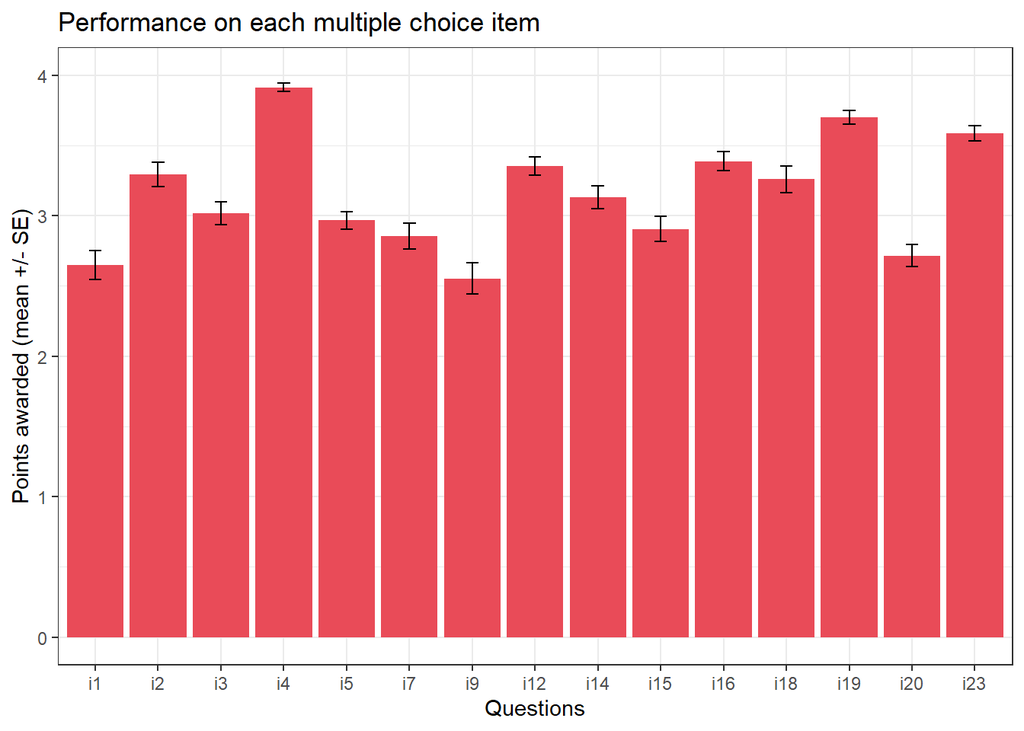

#### Overall performance

As a last step, the descriptives for the performance across all multiple choice items was computed across the whole sample and within each group. The AO group performed slightly better. A t-test revealed that there was no statistically significant difference in performance between both groups.

Descriptives for whole sample

| n | mean | sd | median | trimmed | mad | min | max | range | skew | kurtosis | se |
| --- | --- | --- | --- | --- | --- | --- | --- | --- | --- | --- | --- |
| 116 | 47.27586 | 5.008838 | 48 | 47.54255 | 4.4478 | 31 | 59 | 28 | -0.556915 | 0.5309134 | 0.4650589 |

Descriptives within each group

|  | n | mean | sd | median | trimmed | mad | min | max | range | skew | kurtosis | se |
| --- | --- | --- | --- | --- | --- | --- | --- | --- | --- | --- | --- | --- |
| AO | 62 | 47.79032 | 4.749934 | 48.0 | 47.98000 | 4.4478 | 36 | 59 | 23 | -0.2634870 | -0.0227368 | 0.6032422 |
| non-AO | 54 | 46.68519 | 5.273015 | 47.5 | 47.06818 | 5.1891 | 31 | 55 | 24 | -0.7423773 | 0.5517603 | 0.7175664 |

```
        Two-Sample t-test, t(107.6636) = 1.178883, p = 0.2410437
```

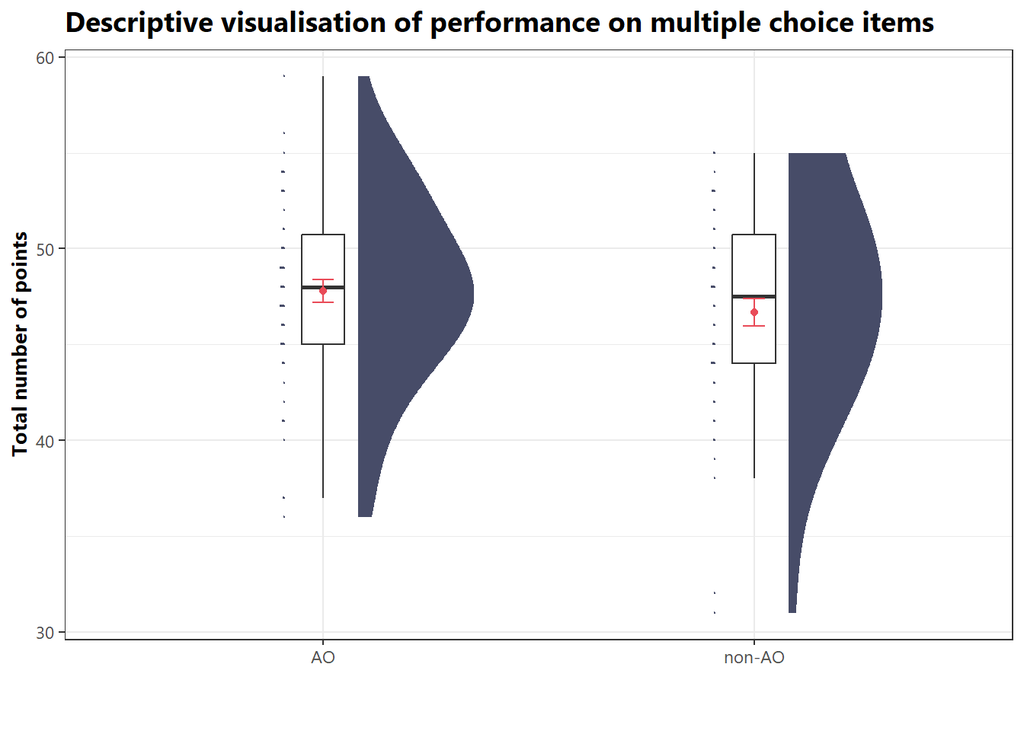

### Learning Outcome Assessment - Totals

Below, the descriptives are shown for the learning outcome assessment in total. No difference between the groups is observed.

Descriptives for whole sample

| n | mean | sd | median | trimmed | mad | min | max | range | skew | kurtosis | se |
| --- | --- | --- | --- | --- | --- | --- | --- | --- | --- | --- | --- |
| 116 | 51.46552 | 6.146658 | 52 | 51.73404 | 5.9304 | 32 | 66 | 34 | -0.5517555 | 0.7907165 | 0.5707029 |

Descriptives within each group

|  | n | mean | sd | median | trimmed | mad | min | max | range | skew | kurtosis | se |
| --- | --- | --- | --- | --- | --- | --- | --- | --- | --- | --- | --- | --- |
| AO | 62 | 51.93548 | 6.007839 | 52 | 52.14000 | 4.4478 | 36 | 66 | 30 | -0.2729610 | 0.3058670 | 0.7629963 |
| non-AO | 54 | 50.92593 | 6.315156 | 52 | 51.31818 | 5.9304 | 32 | 61 | 29 | -0.7995651 | 0.9291188 | 0.8593840 |

```
        Two-Sample t-test, t(110.0664) = 0.8784731, p = 0.3816007
```

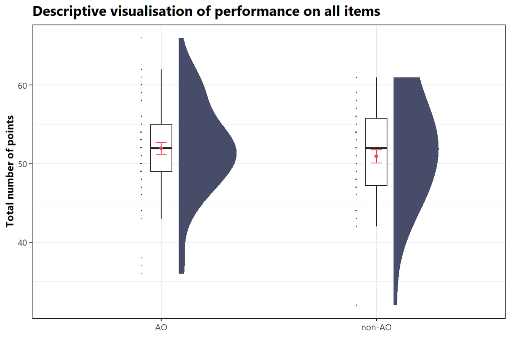

### Results Feedback survey

Feedback regarding the learning outcome assessment was evaluated.

A 5-point Likert scale rating matrix was presented to participants to obtain ratings on the questions. Each item was rated on a scale from -2 (“strongly disagree”) to 2 (“strongly agree”). Raincloud plots were used to visualise distribution and summary statistics for each rating.

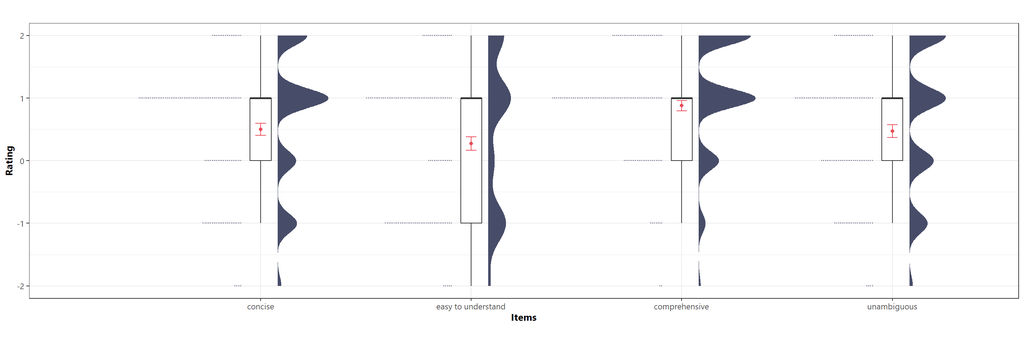

Additional descriptive statistics were computed and included below.

| vars | n | mean | sd | median | trimmed | mad | min | max | range | skew | kurtosis | se |
| --- | --- | --- | --- | --- | --- | --- | --- | --- | --- | --- | --- | --- |
| concise | 116 | 0.5000000 | 1.0508795 | 1 | 0.5425532 | 1.4826 | -2 | 2 | 4 | -0.5571145 | -0.5383779 | 0.0975717 |
| easy to understand | 116 | 0.2758621 | 1.1690666 | 1 | 0.2765957 | 1.4826 | -2 | 2 | 4 | -0.1861897 | -1.2294368 | 0.1085451 |
| comprehensive | 116 | 0.8793103 | 0.8959345 | 1 | 0.9680851 | 0.0000 | -2 | 2 | 4 | -0.8435708 | 0.7453581 | 0.0831854 |
| unambiguous | 116 | 0.4741379 | 1.0911598 | 1 | 0.5106383 | 1.4826 | -2 | 2 | 4 | -0.3326050 | -0.7650704 | 0.1013116 |

Participants were also provided with the option to expand on the rating using comments.

```
##
##
## Some of the questions required specialist knowledge as explained
##
## 8
##
## My knowledge of comprehension, graphemes and morphemes is very limited, meaning there were a few guesses.
##
## I really don't like being asked to guess answers I have no idea about and would suggest not great for the rigor of your survey
##
## Excellent questions!
##
## I think the quiz was focussing on too many aspects of reading.
##
## Are the number of dashes for the missing words equal to the number of letters?
##
## No idea what some of them were on about but don’t know wasn’t an option.  This will corrupt your results.
##
## Some of the terms used I was unsure of the meaning. My feelings may have been different if I better understood some of the questions.
##
## The quiz would be a good springboard for me with regards to motivation for further professional learning as it highlights gaps in current knowledge.
```